# **Cardio Good Fitness Project**

## Background:

Cardio Good Fitness is a retail store that sells high-quality cardiovascular exercise equipments such as treadmills, bikes, ellipticals, rowers etc. There are three different kinds of Treadmill sold here. I have been provided with data about the customers who have brought these different Treadmills.I need to evaluate the data, detect the patterns and come up with insights to improve the business of the store.

## Objective:

1. Come up with a customer profile (characteristics of a customer) of the different products
2. Perform univariate and multivariate analyses
3. Generate a set of insights and recommendations that will help the company in targeting new customers

## Key Questions:

1. Which Treadmill Product is the most effecient?
2. What variables like Age, Income, Usage, Fitness, Miles, Education etc affect the Product sales the most?
3. Does factors like Gender and Marital Status affect the Products?
4. What are the recommendations to the Retail Store to attract new customers?

## Data Description:

- Product - The model no. of the treadmill
- Age - Age of the customer in no of years
- Gender - Gender of the customer
- Education - Education of the customer in no. of years
- Marital Status - Marital status of the customer
- Usage - Avg. # times the customer wants to use the treadmill every week
- Fitness - Self rated fitness score of the customer (5 - very fit, 1 - very unfit)
- Income - Income of the customer
- Miles- Miles that a customer expects to run

### Import the necessary libraries - pandas, numpy, seaborn, matplotlib.pyplot

```python
# Library to suppress warnings or deprecation notes
import warnings
warnings.filterwarnings('ignore')
```

```python
# Libraries to help with reading and manipulating data
import pandas as pd
import numpy as np
import matplotlib.pyplot as plt

# Libraries to help with data visualization
import seaborn as sns
import matplotlib.pyplot as plt
%matplotlib inline
```

### Load the dataset

```python
data = pd.read_csv('CardioGoodFitness.csv')
```

```python
# copying data to another varaible to avoid any changes to original data
df = data.copy()
```

### Check the shape of the dataset

```python
# total number of rows and columns in the file
df.shape
```

```
(180, 9)
```

- The dataset has 180 rows and 9 columns.

### View the first and last few rows of the dataset

```python
# looking at head (5 observations)
df.head()
```

|  | Product | Age | Gender | Education | MaritalStatus | Usage | Fitness | Income | Miles |
| --- | --- | --- | --- | --- | --- | --- | --- | --- | --- |
| 0 | TM195 | 18 | Male | 14 | Single | 3 | 4 | 29562 | 112 |
| 1 | TM195 | 19 | Male | 15 | Single | 2 | 3 | 31836 | 75 |
| 2 | TM195 | 19 | Female | 14 | Partnered | 4 | 3 | 30699 | 66 |
| 3 | TM195 | 19 | Male | 12 | Single | 3 | 3 | 32973 | 85 |
| 4 | TM195 | 20 | Male | 13 | Partnered | 4 | 2 | 35247 | 47 |

```python
# looking at tail (5 observations)
df.tail()
```

|  | Product | Age | Gender | Education | MaritalStatus | Usage | Fitness | Income | Miles |
| --- | --- | --- | --- | --- | --- | --- | --- | --- | --- |
| 175 | TM798 | 40 | Male | 21 | Single | 6 | 5 | 83416 | 200 |
| 176 | TM798 | 42 | Male | 18 | Single | 5 | 4 | 89641 | 200 |
| 177 | TM798 | 45 | Male | 16 | Single | 5 | 5 | 90886 | 160 |
| 178 | TM798 | 47 | Male | 18 | Partnered | 4 | 5 | 104581 | 120 |
| 179 | TM798 | 48 | Male | 18 | Partnered | 4 | 5 | 95508 | 180 |

**Observations**

- Product, Gender and MaritalStatus and String variables.
- Age, Education, Usage, Fitness, Income and Miles are Numerical variables.
- Product - The model no. of the treadmill
- Age - Age of the customer in no of years
- Gender - Gender of the customer
- Education - Education of the customer in no. of years
- Marital Status - Marital status of the customer
- Usage - Avg. # times the customer wants to use the treadmill every week
- Fitness - Self rated fitness score of the customer (5 - very fit, 1 - very unfit)
- Income - Income of the customer
- Miles- Miles that a customer expects to run

### Check the info()

```python
df.info()
```

```
<class 'pandas.core.frame.DataFrame'>
RangeIndex: 180 entries, 0 to 179
Data columns (total 9 columns):
 #   Column         Non-Null Count  Dtype
---  ------         --------------  -----
 0   Product        180 non-null    object
 1   Age            180 non-null    int64
 2   Gender         180 non-null    object
 3   Education      180 non-null    int64
 4   MaritalStatus  180 non-null    object
 5   Usage          180 non-null    int64
 6   Fitness        180 non-null    int64
 7   Income         180 non-null    int64
 8   Miles          180 non-null    int64
dtypes: int64(6), object(3)
memory usage: 12.8+ KB
```

**Observations**

- All columns have 180 observations. Hence there are no missing values.
- Product, Gender and MaritalStatus are object datatype i.e String data type in Python.
- All other columns are Integer datatypes.
- Product, Gender and MaritalStatus should be changed to Categorical variables as they have limited set of values.

## Data Preprocessing

### Fixing the datatypes

```python
# categorical column should be converted to categorical type
# (It reduces the data space required to store the dataframe,
# every class in the categorical column will be represented by a number under the hood.
# This is useful during model building)

df['Product'] = df.Product.astype('category')
df['Gender'] = df.Gender.astype('category')
df['MaritalStatus'] = df.MaritalStatus.astype('category')
```

```python
df.info()
```

```
<class 'pandas.core.frame.DataFrame'>
RangeIndex: 180 entries, 0 to 179
Data columns (total 9 columns):
 #   Column         Non-Null Count  Dtype
---  ------         --------------  -----
 0   Product        180 non-null    category
 1   Age            180 non-null    int64
 2   Gender         180 non-null    category
 3   Education      180 non-null    int64
 4   MaritalStatus  180 non-null    category
 5   Usage          180 non-null    int64
 6   Fitness        180 non-null    int64
 7   Income         180 non-null    int64
 8   Miles          180 non-null    int64
dtypes: category(3), int64(6)
memory usage: 9.5 KB
```

- Now there are 6 numeric columns and 3 categorical columns.

### Summary of the data

```python
#view some basic statistical details like percentile, mean, std etc.
df.describe().T  # .T is to transpose the rows and columns of the result
```

|  | count | mean | std | min | 25% | 50% | 75% | max |
| --- | --- | --- | --- | --- | --- | --- | --- | --- |
| Age | 180.0 | 28.788889 | 6.943498 | 18.0 | 24.00 | 26.0 | 33.00 | 50.0 |
| Education | 180.0 | 15.572222 | 1.617055 | 12.0 | 14.00 | 16.0 | 16.00 | 21.0 |
| Usage | 180.0 | 3.455556 | 1.084797 | 2.0 | 3.00 | 3.0 | 4.00 | 7.0 |
| Fitness | 180.0 | 3.311111 | 0.958869 | 1.0 | 3.00 | 3.0 | 4.00 | 5.0 |
| Income | 180.0 | 53719.577778 | 16506.684226 | 29562.0 | 44058.75 | 50596.5 | 58668.00 | 104581.0 |
| Miles | 180.0 | 103.194444 | 51.863605 | 21.0 | 66.00 | 94.0 | 114.75 | 360.0 |

**Observations**

- Age of the customers varies from 18 to 50 indicating the products are used by customers of all ages. Average age is 28.78 and median age is 26.
- Customers have minimum 12 years and maximum 21 years of education. It means Customers ranges from High School graders to University Post Graduates.
- Customers use the product minimum 2 times and maximum 7 times in a week.
- The Fitness level of the customers ranges from 1 to 5 with 5 being the fittest.
- The Mean and Median of Education (15.57 and 16), Usage(3.45 and 3) and Fitness(3.31 and 3) are very close values which indicates an almost symmetric distribution.
- Miles expected to run ranges from 21 to as high as 360 miles.The mean being 103.19 miles and median is 94 miles.
- The income range is very wide i.e. 29562 to 104581 which indicates customers with varied houshold income use the products.The mean of the income is 53719.57 and median is 50596.5.
- There is a huge difference between the 3rd quartile and the maximum value for the Age, Income and Miles indicating there might be outliers to the right in these variables

### Summary of non-numeric variables

```python
#exclude the numeric variables
df.describe(exclude='number').T
```

|  | count | unique | top | freq |
| --- | --- | --- | --- | --- |
| Product | 180 | 3 | TM195 | 80 |
| Gender | 180 | 2 | Male | 104 |
| MaritalStatus | 180 | 2 | Partnered | 107 |

**Observations**

- There are 3 kinds of Treadmill Products that the customers are buying.
- Gender and Marital status have 2 categories each.
- TM195 is the widely purchased product with 80 sales.
- Out of 180 customers, 104 were male. Hence Male customers are buying Treadmills more.
- Majority of the customers buying Treadmills have partners, i.e , 107 customers out of 180 are partnered.

**Let's check the count of each unique category in each of the categorical variables.**

```python
#Making a list of all catrgorical variables
cat_col=['Product', 'Gender', 'MaritalStatus']

#Printing number of count of each unique value in each column
for column in cat_col:
    print(df[column].value_counts())
    print('-'*50)
```

```
TM195    80
TM498    60
TM798    40
Name: Product, dtype: int64
--------------------------------------------------
Male      104
Female     76
Name: Gender, dtype: int64
--------------------------------------------------
Partnered    107
Single        73
Name: MaritalStatus, dtype: int64
--------------------------------------------------
```

**Observations**

- There are three types of Treadmill Products where TM195 is used by most number of customers and TM798 is used by least number of customers.
- Male customers are buying the Treadmill Products more than Female customers.
- Partnered customers are buying the Treadmill Products more than Single customers.

### Check Missing values

```python
df.isnull().sum()
```

```
Product          0
Age              0
Gender           0
Education        0
MaritalStatus    0
Usage            0
Fitness          0
Income           0
Miles            0
dtype: int64
```

- No Missing Values found

### Check Duplicate values

```python
df.duplicated().sum()
```

```
0
```

- No Duplicate Values found

# EDA

## Univariate Analysis

### Let us explore the numerical variables first

```python
# While doing uni-variate analysis of numerical variables we want to study their central tendency
# and dispersion.
# Let us write a function that will help us create a boxplot, histogram and violinplot for any input numerical
# variable.
# This function takes the numerical column as the input and returns the boxplots,
# boxplot, histogram and violin plots for the variable.

# function to plot a boxplot, histogram and violinplot  along the same scale.


def box_hist_violin(data, figsize=(15, 7), kde=False, bins=None):
    """
    Boxplot, Histogram, Distplot and ViolinPlot combined

    data: dataframe
    feature: dataframe column
    figsize: size of figure (default (15,7))
    kde: whether to show the density curve (default False)
    bins: number of bins for histogram (default None)
    """

    f2, (ax_box2, ax_hist2, ax_violin2) = plt.subplots(
        nrows=3,  # Number of rows of the subplot grid= 3
        sharex=True,  # x-axis will be shared among all subplots
        gridspec_kw={"height_ratios": (1.0, 1.0, 1.0)},
        figsize=figsize,
    )  # creating the 3 subplots



    sns.boxplot( x=data, ax=ax_box2, showmeans=True, color="violet")
    # boxplot will be created and a star will indicate the mean value of the column

    sns.histplot(
        x=data, kde=kde, ax=ax_hist2, bins=bins, palette="winter", color="green"
    ) if bins else sns.histplot(
        x=data, kde=kde, ax=ax_hist2, color="green"
    )  # For histogram
    ax_hist2.axvline( data.mean(), color='g', linestyle="--")  # Add mean to the histogram
    ax_hist2.axvline( data.median(), color='r', linestyle='dashed')  # Add median to the histogram
    ax_hist2.axvline( data.mode()[0], color="black", linestyle='solid')  # Add median to the histogram
    ax_hist2.legend({'Mean':data.mean(),'Median':data.median(),'Mode':data.mode()})

    sns.violinplot(x=data,  ax=ax_violin2, showmeans=True) #violin plot will be created
```

**Univariate Analysis of Age**

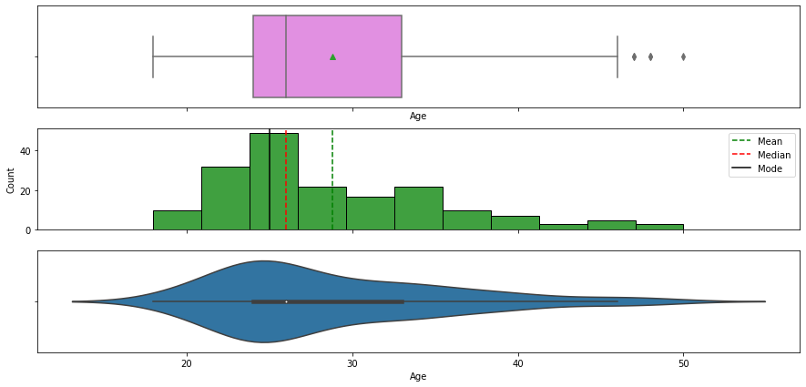

```python
box_hist_violin(df.Age)
```

**Observations**

- Age is skewed towards the right.
- Mean age is 28, Median is 26 and Mode is 25. This indicated that Young customers are buying more treadmills.
- The oldest person buying the treadmill is aged 50.
- Very few customers with age less than 20 and greater then 40 are buying treadmills.

**Univariate Analysis of Education**

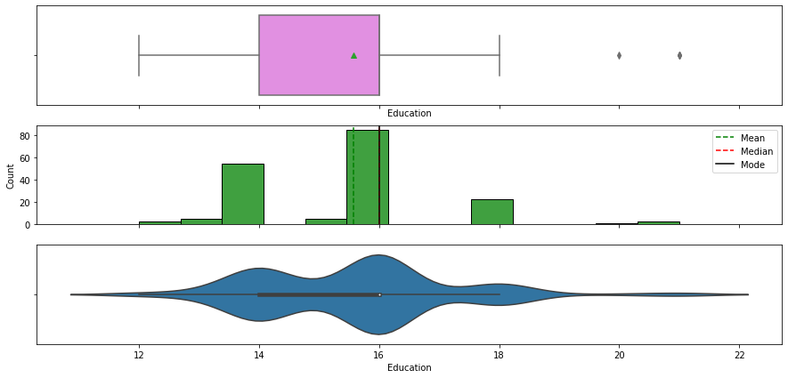

```python
box_hist_violin(df.Education)
```

**Observations**

- Mode and Median for Education is the same which is 16 years.It means most of the cutomers are University Bachelor graduates. Mean is around 15.5 which is slightly less than the Median indicating the graph is slightly skewed to the left.
- There are only very few outliers to the right indicating very few customers who are University post graduates with more than 18 years of education are buying the Products.

**Univariate Analysis of Usage**

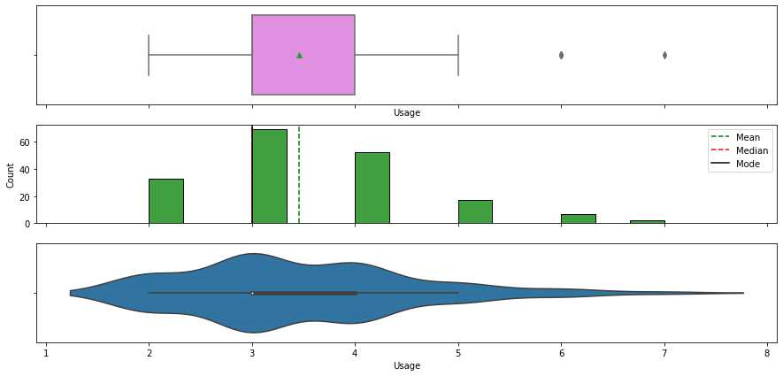

```python
box_hist_violin(df.Usage)
```

**Observations**

- Mode and Median is 3 for Usage. Mean is slightly more than 3.
- The graph is slightly skewed to the right and there are few outliers to the right.
- Very few customers use the product more than 5 times a week.

**Univariate Analysis of Fitness**

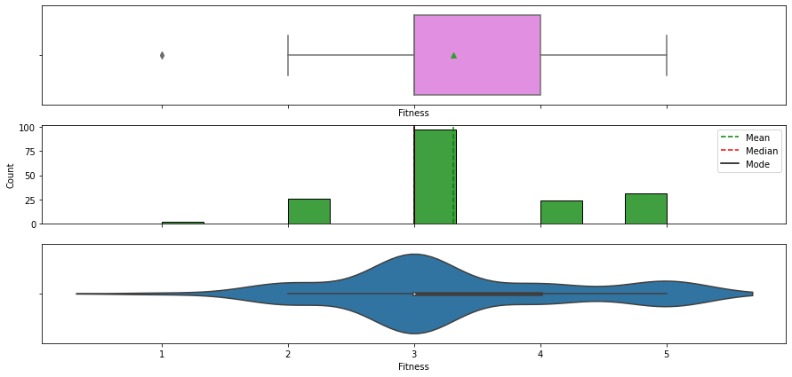

```python
box_hist_violin(df.Fitness)
```

**Observations**

- Mode and Median is 3 for Fitness. Mean is slightly more than 3. It means most customers have Fitness level 3 which is a Moderately Fit level.
- The graph is slightly skewed to the right.
- Only few customers consider themselves unfit or very fit as most of them consider themselves as Moderately Fit.

**Univariate Analysis of Income**

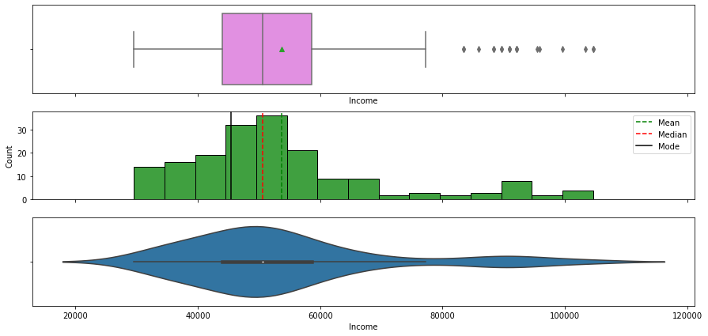

```python
box_hist_violin(df.Income)
```

**Observations**

- Most of the customers have income in the range of 30000 to 70000.
- Mean is around 53000 and median is around 50000.
- The graph is slightly skewed to the right and there are few outliers to the right.
- Only few customers buying the product have income more than 80000 and less than 30000.

**Univariate Analysis of Miles**

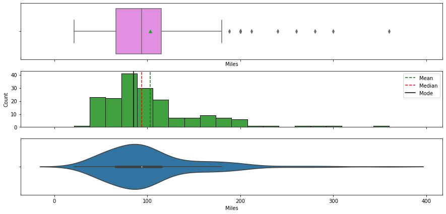

```python
box_hist_violin(df.Miles)
```

**Observations**

- Majority of the customers are expecting to run 40 to 120 miles per week. Most of them are targetting 80 miles per week.
- Mean is around 103 and median is around 94.
- The graph is slightly skewed to the right and there are some outliers to the right.
- Only few customers expecting to run more than 200 miles per week.

### Let us now explore the categorical variables

```python
# function to create labeled barplots


def labeled_barplot(data, feature, perc=False, n=None):
    """
    Barplot with percentage at the top

    data: dataframe
    feature: dataframe column
    perc: whether to display percentages instead of count (default is False)
    n: displays the top n category levels (default is None, i.e., display all levels)
    """

    total = len(data[feature])  # length of the column
    count = data[feature].nunique()
    if n is None:
        plt.figure(figsize=(count + 1, 5))
    else:
        plt.figure(figsize=(n + 1, 5))

    plt.xticks(rotation=90, fontsize=15)
    ax = sns.countplot(
        data=data,
        x=feature,
        palette="Paired",
        order=data[feature].value_counts().index[:n].sort_values(),
    )

    for p in ax.patches:
        if perc == True:
            label = "{:.1f}%".format(
                100 * p.get_height() / total
            )  # percentage of each class of the category
        else:
            label = p.get_height()  # count of each level of the category

        x = p.get_x() + p.get_width() / 2  # width of the plot
        y = p.get_height()  # height of the plot

        ax.annotate(
            label,
            (x, y),
            ha="center",
            va="center",
            size=12,
            xytext=(0, 5),
            textcoords="offset points",
        )  # annotate the percentage

    plt.show()  # show the plot
```

**Univariate Analysis of Product**

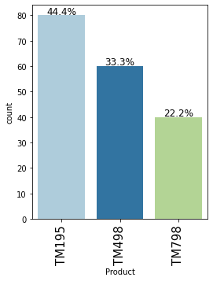

```python
plt.figure(figsize=(10,7))
labeled_barplot(df, 'Product', perc=True)
```

**Observations**

- The most purchased model is TM195 with 44.4% of customers buying it.
- The least purchased model is TM798 with only 22.2% of customers buying it.
- The remaining model TM498 was purchased by 33.3% of customers.

**Univariate Analysis of Gender**

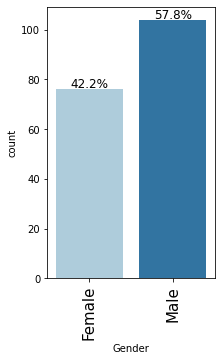

```python
plt.figure(figsize=(10,7))
labeled_barplot(df, 'Gender', perc=True)
```

**Observations**

- 57.8% of the customers buying the product are males.
- Hence Males are buying the product more than females.

**Univariate Analysis of MaritalStatus**

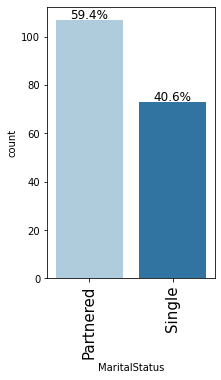

```python
plt.figure(figsize=(10,7))
labeled_barplot(df, 'MaritalStatus', perc=True)
```

**Observations**

- 59.4% of the customers buying the product are having a partner..
- Hence Partnered customers are buying the product more than Single customers.

## Bivariate Analysis

**Plot bivariate charts between variables to understand their interaction with each other.**

### Correlation

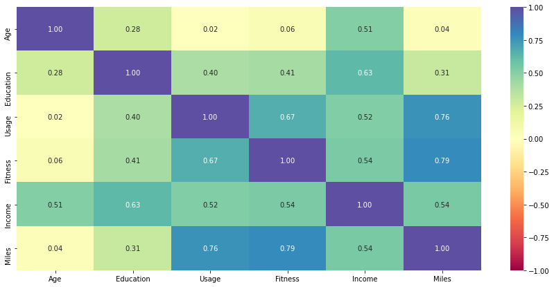

```python
# Check for correlation among numerical variables
num_var = ['Age','Education','Usage','Fitness','Income','Miles']

corr = df[num_var].corr()

# plot the heatmap

plt.figure(figsize=(15, 7))
sns.heatmap(corr, annot=True, vmin=-1, vmax=1, fmt=".2f", cmap="Spectral", xticklabels=corr.columns, yticklabels=corr.columns)
plt.show()
```

**Observations**

- Miles, Usage and Fitness have stron correlation with each other. As more number of miles are covered, there is more Usage and Fitness level will also increase. Similary with more Usage , more miles are covered. And with more Fitness there is more Usage.
- Age and income have significant correlation.
- Age has almost no corelation with Usage, Fitness and Miles.
- Age has some correlation with Education.
- Education has significant correlation with income. Higher education makes way to higher income.
- Education has some correlation with Usage,Fitness and Miles.
- Income has almost the same amount of correlation with Age, Usage, Fitness, Miles and a bit more strong correlation with Income.

### Bivariate Scatter Plots

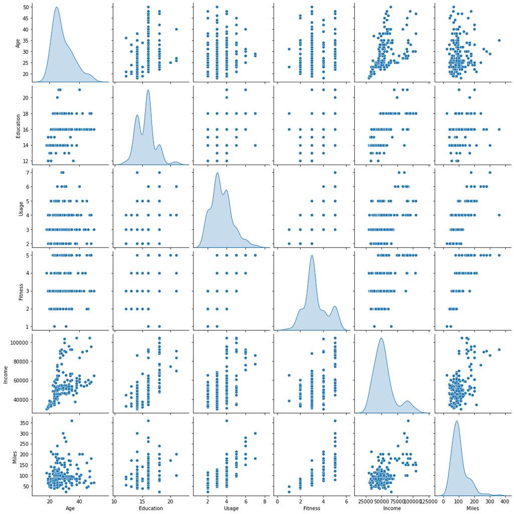

```python
sns.pairplot(data=df[num_var], diag_kind="kde")
plt.show()
```

**Observations**

- We get the same insights as from the correlation plot

### Relationship Between Product and Numerical variables.

```python
#Average age of customer buying each model
df.groupby('Product')['Age'].mean()
```

```
Product
TM195    28.55
TM498    28.90
TM798    29.10
Name: Age, dtype: float64
```

**Observations**

- Average age of customers buying the three Products are 28.55, 28.90 and 29.10 which are very close values. So there is no significant relation of age with the Products.

```python
#Average Income of customer buying each model
df.groupby('Product')['Income'].mean()
```

```
Product
TM195    46418.025
TM498    48973.650
TM798    75441.575
Name: Income, dtype: float64
```

**Observations**

- Average Income of customers buying TM195 is 46418.025
- Average Income of customers buying TM498 is a bit more which is 48973.650.
- Average Income of customers buying TM798 is the highest which is 75441.575.
- Customers with less income are buying TM195 and customers with more income are buying TM798.

```python
#Average Miles expected to cover for each model
df.groupby('Product')['Miles'].mean()
```

```
Product
TM195     82.787500
TM498     87.933333
TM798    166.900000
Name: Miles, dtype: float64
```

**Observations**

- Customers buying TM798 are expecting to cover an average of 166.90 miles as compared to customers who are buying TM195 who are expecting to cover 82.78 miles on average.
- Customers buying TM498 expect to cover 87.93 miles.

```python
#Average Usage of customer buying each model
df.groupby('Product')['Usage'].mean()
```

```
Product
TM195    3.087500
TM498    3.066667
TM798    4.775000
Name: Usage, dtype: float64
```

**Observations**

- Customers buying TM195 and TM498 have almost the same average usage of 3.08 and 3.06 times per week respectively.
- Customers buying TM798 have a bit higher average usage of 4.77 times per week.

```python
#Average Education of customer buying each model
df.groupby('Product')['Education'].mean()
```

```
Product
TM195    15.037500
TM498    15.116667
TM798    17.325000
Name: Education, dtype: float64
```

**Observations**

- Customers buying TM195 and TM498 have almost the same Education of 15.03 and 15.11 in number of years respectively , which is almost equal to University Graduate degree.
- Customers buying TM798 have an average of 17.32 years of Education which indicates they are mostly University post Graduates.

```python
#Average Fitness of customer buying each model
df.groupby('Product')['Fitness'].mean()
```

```
Product
TM195    2.9625
TM498    2.9000
TM798    4.6250
Name: Fitness, dtype: float64
```

**Observations**

- Customers buying TM195 and TM498 have almost the same average Fitness Levels of 2.96 and 2.90 respectively.
- Customers buying TM798 have an average of 4.62 Fitness Level which is a really high level indicating Very Fit customers.

### Let us now Analyse with the help of Graphs

**Relationship of Product with Numeric Variables**

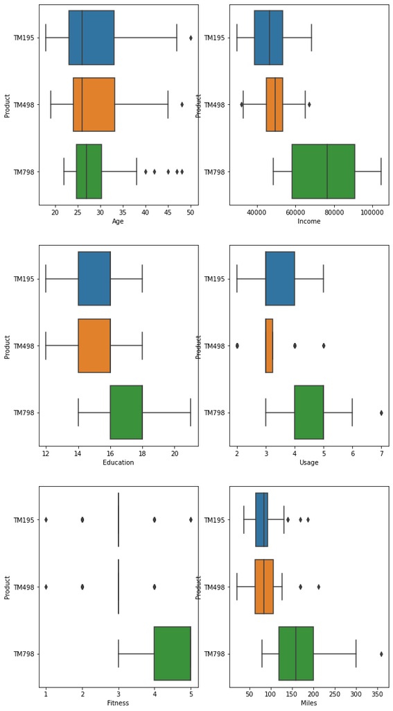

```python
#BiVaraite Analysis for Product with Numeric Variables

fig, ax1 =plt.subplots(3,2,figsize=(10, 20))
col_list=['Age','Income','Education','Usage','Fitness','Miles']
for i in range(len(col_list)):
   row=i//2
   col=i%2
   ax=ax1[row,col]

   sns.boxplot(df[col_list[i]],df['Product'],ax=ax)
```

**Observations**

- More young people between the Age 25-30 are buying TM798. Whereas TM195 and TM498 are being bought by more people in the age group 20-35.
- There are many outliers towards the right for TM798 indicating some people over the age of 40 are buying it.
- Customers with less income in the range 40k to 50 k are buying TM195 and customers with higher income in the range 60k to 90k are buying TM798. This could be beacuse the cost of TM798 is higher than the other models.
- Customers buying TM195 and TM498 have almost the same Education range of 14 to 16 years, which is almost equal to University Graduate degree. Customers buying TM798 have mostly 16 to 18 years Education which indicates they are mostly University post Graduates.
- Customers buying TM798 are expecting to cover 100 to 200 miles as compared to customers who are buying TM195 and TM498 who are expecting to 50 to 100 miles
- Customers buying TM195 use it mostly 3 to 4 times a week. But customers buying TM498 only using 3 times a week with some outliers.Customers buying TM798 are planning use of mostly 4 to 5 times a week with some outliers to the right.
- Customers buying TM195 and TM498 have almost the same average Fitness Levels of 3 and some outliers on both right and left. Customers buying TM798 have Fitness Levels mostly from 4 to 5 which is a really high level indicating Very Fit customers.

**Relationship of Gender with Numeric Variables**

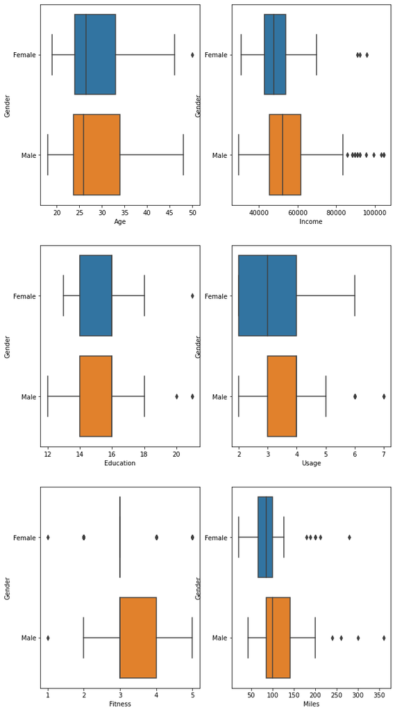

```python
#BiVaraite Analysis for Gender with Numeric Variables

fig, ax1 =plt.subplots(3,2,figsize=(10, 20))
col_list=['Age','Income','Education','Usage','Fitness','Miles']
for i in range(len(col_list)):
   row=i//2
   col=i%2
   ax=ax1[row,col]

   sns.boxplot(df[col_list[i]],df['Gender'],ax=ax)
```

**Observations**

- Age range of Male and female customers are almost the same with female mostly in the range 22-33 and male 21-35. More number of older males as compared to females are buying the product.
- Male customers are earning more income than female customers.
- Education of female and male customers are almost the same.
- Female usage varies mostly from 2 to 4 times a week wheres Male usage is mostly 3 to 4 times a week with some outliers to the right. Thus Male customers are expected to use the Products more.
- Female customers have mostly rated Fitness Level as 3 with some outliers on both sides. But Most male customers have 3 to 4 fitness levels.
- The miles expected to cover by female customers is very less compared to Male customers.

**Relationship of Marital Status with Numeric Variables**

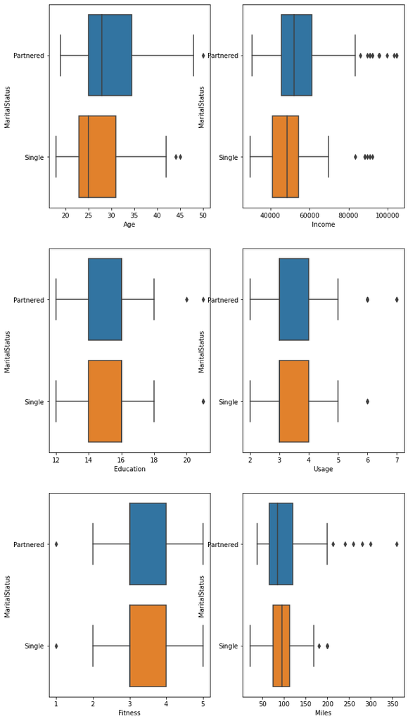

```python
#BiVaraite Analysis for MaritalStatus with Numeric Variables

fig, ax1 =plt.subplots(3,2,figsize=(10, 20))
col_list=['Age','Income','Education','Usage','Fitness','Miles']
for i in range(len(col_list)):
   row=i//2
   col=i%2
   ax=ax1[row,col]

   sns.boxplot(df[col_list[i]],df['MaritalStatus'],ax=ax)
```

**Observations**

- Single Customers are younger in age than Partnered customers.
- Partnered Customers are earning more than Single customers.
- Education of Single and Partnered customers are almost the same.
- Usage of Single and Partnered customers are also almost the same. Partnered customers have more outliers to the right.
- Fitness levels of Single and Partnered customers are almost the same.
- Miles covered by Partnered customers are more than that of Single customers.

**Relationship of Product with Gender**

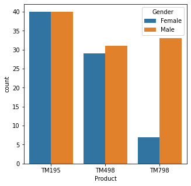

```python
plt.figure(figsize=(5,5))
sns.countplot(data=df,x='Product',hue='Gender')
plt.show()
```

**Observations**

- Both Male and Female customers are equally buying TM195.
- TM498 is bought a little more by males than females.
- TM798 is bought by a significantly higher number of males than females.

**Relationship of Product with Marital Status**

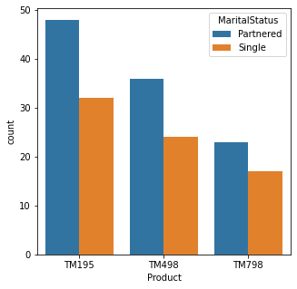

```python
plt.figure(figsize=(5,5))
sns.countplot(data=df,x='Product',hue='MaritalStatus')
plt.show()
```

**Observations**

- In case of all the 3 products Partnered customers are buying the products more than Single customers.

**Relationship of Gender with Marital Status**

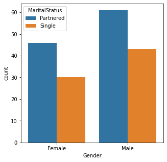

```python
plt.figure(figsize=(5,5))
sns.countplot(data=df,x='Gender',hue='MaritalStatus')
plt.show()
```

**Observations**

- In case of both Male and Female customers, there are more Partnered people than single people.

## Multivariate Analysis

### Checking the Relation between Product,Gender,MaritalStatus and Age

```python
# Checking the Average Age across Product,Gender and MaritalStatus
df.groupby(by = ['Product','Gender','MaritalStatus'])['Age'].mean()
```

```
Product  Gender  MaritalStatus
TM195    Female  Partnered        28.333333
                 Single           28.692308
         Male    Partnered        31.380952
                 Single           25.631579
TM498    Female  Partnered        30.000000
                 Single           28.142857
         Male    Partnered        30.380952
                 Single           25.200000
TM798    Female  Partnered        29.000000
                 Single           24.333333
         Male    Partnered        30.000000
                 Single           28.928571
Name: Age, dtype: float64
```

**Observations**

- The highest Average age of 31.38 is observed for Male customers with Partners who are buying Model TM195.
- The lowest Average age of 24.33 is observed for Female customers who are single and buying Model TM798.

**Checking the Relation between Education, Income and Product**

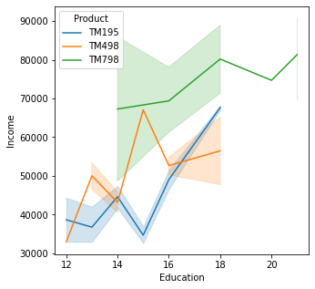

```python
plt.figure(figsize=(5,5))
sns.lineplot(data=df,x='Education',y='Income',hue='Product')
plt.show()
```

**Observations**

- For all three products , Income increases with increase in years of Education.
- Customers with less Education have less Income and they prefer to buy the Product TM195 as it might be less costly.
- Customers with a middle range of income prefer to buy TM498.
- Customers with higher Education have high income and they prefer to buy the Product TM798 as they can afford it.

**Checking the Relation between Usage, Miles and Product**

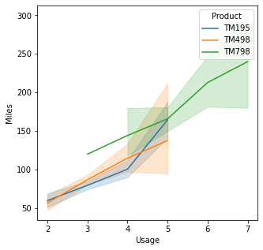

```python
plt.figure(figsize=(5,5))
sns.lineplot(data=df,x='Usage',y='Miles',hue='Product')
plt.show()
```

### Heat maps to compare the three Products

**TM798**

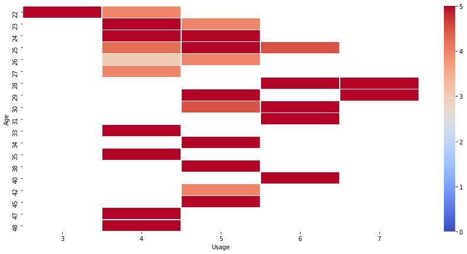

```python
df_man = df[df.Product=='TM798']
df_hm =df_man.pivot_table(index = 'Age',columns ='Usage',values ='Fitness')
# Draw a heatmap
plt.figure(figsize = (15,7)) # To resize the plot
sns.heatmap(df_hm,  fmt="d", cmap='coolwarm', linewidths=.5, vmin=0)
plt.show()
```

**Observations**

- TM798 has high Fitness levels throughout with all age groups.
- Most Usage is for Level 4 and 5 . And the least one is for Level 3.
- Customers with age 28 and 29 have highest usage of 6 and 7 times per week.
- Customers with Age 31 to 48 have high Fitness levels and Usage between 4 and 6.

**TM498**

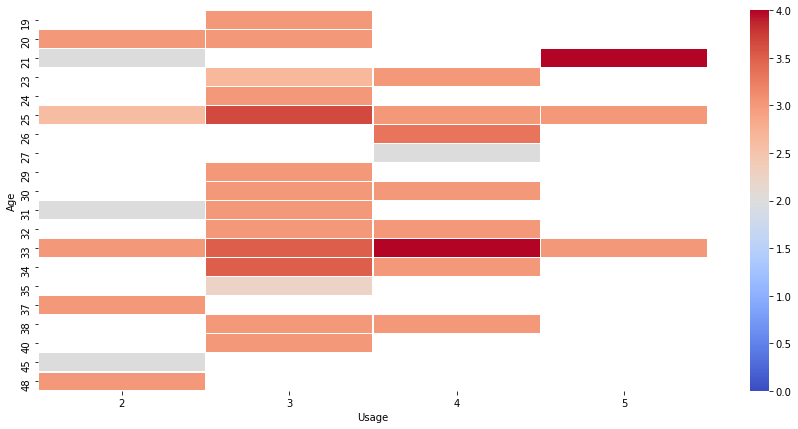

```python
df_man = df[df.Product=='TM498']
df_hm =df_man.pivot_table(index = 'Age',columns ='Usage',values ='Fitness')
# Draw a heatmap
plt.figure(figsize = (15,7)) # To resize the plot
sns.heatmap(df_hm,  fmt="d", cmap='coolwarm', linewidths=.5, vmin=0)
plt.show()
```

**Observations**

- TM498 does not have as high Fitness level as TM798 with the highest being 4.
- Customers aged 21 had highest usage of 5 with Fitness Level 4.
- There are many customers with Usage as low as 2 times per week and Fitness levels less than 3.
- Most customers have Usage 3 times per week.

**TM195**

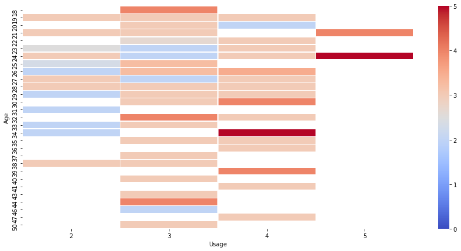

```python
df_man = df[df.Product=='TM195']
df_hm =df_man.pivot_table(index = 'Age',columns ='Usage',values ='Fitness')
# Draw a heatmap
plt.figure(figsize = (15,7)) # To resize the plot
sns.heatmap(df_hm,  fmt="d", cmap='coolwarm', linewidths=.5, vmin=0)
plt.show()
```

**Observations**

- Most customers have Usage levels 3 and 4.
- Customers with Usage 2 times per week have very less fitness levels.
- Customers of all ages enjoy this Product more comapared to TM798 and TM498.

### Catplot to demonstrate relation between Fitness, Income, Product, Gender

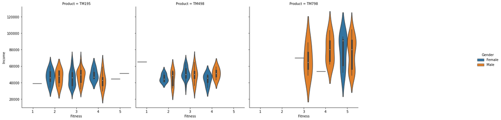

```python
sns.catplot(x='Fitness',
            y='Income',
             col='Product',
            hue='Gender',
             data=df,
             col_wrap=4,
             kind="violin")
plt.show()
```

**Observations**

- TM195 has similar graphs for Male and Female customers over different Fitness Levels and Income. The income does not exceed 80k and Fitness Level ranges from 2 to 4.
- TM498 has been bought by Male and Female customers with much lesser income compared to TM195 for some Fitness levels such as 2 and 4. The income does not exceed 80k and Fitness Level ranges from 2 to 4.
- TM798 have fitness Levels from 3 to as high as 5. And the income levels are higher than Customers of the previous Products.

**Let's have a quick final overview of the data using the pandas profiling library.**

```python
# let us try pandas-profiling now and see how does it simplifies the EDA
# !pip install pandas-profiling==2.8.0
```

```python
pip install pandas-profiling
```

```python
#import pandas_profiling
from pandas_profiling import ProfileReport
# Use the original dataframe, so that original features are considered
prof = ProfileReport(data)
# to view report created by pandas profile
prof
```

[interactive chart not shown]

```python
# to save report obtained via pandas profiling
prof.to_file(output_file='output.html')
```

# **Conclusion and Recommendations**

## Conclusion

We have been able to conclude that

- TM195 is the most bought Treadmill. It is also the cheapest and attracts customers with low income and less Usage.
- TM798 is the least bought Treadmill. It is bought by customers with High Education, Good income and who have High Fitnes Levels.They also expect to cover longer miles.
- Male Customers are buying Treadmills more than the female customers.
- Customers with Partners are buying Treadmills more than the Single customers.
- All three treadmills are mainly used by the younger generation of age 20-35.
- Miles, Usage and Fitness have strong correlation with each other. As more number of miles are covered, there is more Usage and Fitness level will also increase. Similary with more Usage , more miles are covered. And with more Fitness there is more Usage.
- Age has almost no corelation with Usage, Fitness and Miles.
- Education has significant correlation with income. Higher education makes way to higher income.

## Recommendation to business

- As young generation are the main customers, attract more young customers by using a youth icon as Ambassador.
- As there are less Female customers when compared to Males, organize and sponsor Women Fitness Awareness Programmes so they become more aware of the Products.
- As there are less customers above the age of 35, more ads should be designed in a way that should reach out to the older customers as well.
- TM195 being the cheaper model should be able to attract wide range of customers with less income.
- As TM798 is used by Very Fit customers , it should be projected to be the Treadmill King of Fitness and more fitness enthusiasts should be able to buy them.